# AS06

陳芸霠

2025-05-10

# 新聞標題： 超高齡社會來臨 長照機構照顧人力足夠嗎？

## 資料

```r
raw <- read_excel(path = "data/AS06_data.xlsx", sheet = 1, skip = 2)

raw %>%
    head()
```

```
## # A tibble: 6 × 14
##   性別  老人機構工作人員別 國籍別 縣市別 `103年` `104年` `105年` `106年` `107年`
##   <chr> <chr>              <chr>  <chr>  <chr>   <chr>   <chr>   <chr>   <chr>
## 1 總計  　院長(主任)       　本國籍…… 衛福部直轄… -       28      39      54      32
## 2 總計  　院長(主任)       　本國籍…… 新北市 -       248     208     218     208
## 3 總計  　院長(主任)       　本國籍…… 臺北市 -       130     118     110     108
## 4 總計  　院長(主任)       　本國籍…… 桃園市 -       60      63      63      65
## 5 總計  　院長(主任)       　本國籍…… 桃園縣 -       -       -       -       -
## 6 總計  　院長(主任)       　本國籍…… 臺中市 -       126     124     131     68
## # ℹ 5 more variables: `108年` <chr>, `109年` <chr>, `110年` <chr>,
## #   `111年` <chr>, `112年` <chr>
```

```r
data <- raw %>%
    rename(gender = 性別, staff = 老人機構工作人員別, nationality = 國籍別, county = 縣市別, `103` = `103年`, `104` = `104年`, `105` = `105年`, `106` = `106年`, `107` = `107年`, `108` = `108年`, `109` = `109年`, `110` = `110年`, `111` = `111年`, `112` = `112年`) %>%
    mutate_all(~na_if(., "-")) %>%
    mutate(county = case_when(
        county %in% c("桃園縣", "桃園市") ~ "桃園市",
        TRUE ~ county)) %>%
    mutate(staff = str_replace_all(staff, "\u3000", ""),
           nationality = str_replace_all(nationality, "\u3000", "")) %>%
    mutate(staff = case_when(
        staff %in% c("院長(主任)", "行政人員(含主任)") ~ "行政人員(院長、主任)",
        TRUE ~ staff)) %>%
    mutate(across(c(staff, nationality, county), as.factor),
           across(starts_with(c("10","11")), as.numeric)) %>%
    select(-gender)
```

資料處理：在老人長照機構中，「服務人員」作為基本照顧服務人力，是機構是否能夠提供好的照顧服務的關鍵之一，需要的人力也最多。「服務人員」在資料中包含照顧服務員、外籍看護工（104年後獨立成項）及服務相關之專業人員，顯示此一工作目前也仰賴外籍移工的協助。

以下計算各縣市在112年時，機構雇用外國籍服務人員的比例，並依照比例高低程度分為三組，以在地圖上進行視覺化。

```r
foreign_ratio <- data %>%
    filter(staff == "服務人員") %>%
    group_by(county, nationality) %>%
    summarise(count_112 = sum(`112`, na.rm = TRUE), .groups = "drop") %>%
    group_by(county) %>%
    mutate(total = sum(count_112),
           proportion = round(count_112 / total, 3))  %>%
    filter(nationality == "外國籍")
```

```r
quantiles <- quantile(foreign_ratio$proportion, probs = c(0, 1/3, 2/3, 1), na.rm = TRUE)

ratio_grouped <- foreign_ratio %>%
    mutate(group = cut(
    proportion,
    breaks = quantiles,
    labels = c("低", "中（>36%）", "高（>41%）"),
    include.lowest = TRUE)) %>%
    filter(county != "衛福部直轄(所屬)機構") %>%
    select(county, proportion, group)
```

```r
library(sf)

ratio_map <- st_read("data/shapefiles/COUNTY_MOI_1090820.shp") %>%
    st_simplify(dTolerance = 100) %>%
    right_join(ratio_grouped, by=c("COUNTYNAME"="county"))
```

```r
taiwan_bbox <- st_bbox(c(
  xmin = 118, xmax = 123,
  ymin = 21.8, ymax = 26.5), crs = st_crs(ratio_map))

map <- st_crop(ratio_map, taiwan_bbox)
```

圖一

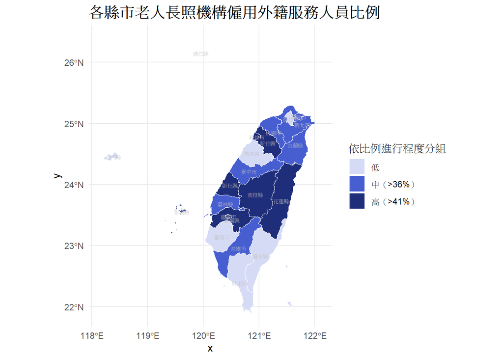

```r
map %>%
    ggplot(aes(fill = group)) +
    geom_sf(color="white", size=0.1) +
    scale_fill_manual(values = c(
    "低" = "#D6DBF5",
    "中（>36%）" = "#475ED1",
    "高（>41%）" = "#1F2E7A" )) +
    labs(fill = "依比例進行程度分組",
    title = "各縣市老人長照機構僱用外籍服務人員比例")+
    theme_minimal() +
    theme(plot.title = element_text(size = 15, face = "bold"))+
    geom_sf_text(aes(label = COUNTYNAME), size = 2, color = "gray")
```

```r
df_long <- data %>%
    filter(staff == "服務人員") %>%
    pivot_longer(cols = `103`:`112`, names_to = "year", values_to = "count")

result <- df_long %>%
    group_by(county, year, nationality) %>%
    summarise(count = sum(count, na.rm = TRUE), .groups = "drop") %>%
    group_by(county, year) %>%
    mutate(total = sum(count),
           proportion = round(count / total, 3)) %>%
    ungroup()

trend_data <- result %>%
    group_by(nationality, year) %>%
    summarise(num = sum(count, na.rm = TRUE), .groups = "drop") %>%
    group_by(year) %>%
    mutate(total = sum(num),
           proportion = round(num / total, 3)) %>%
    select(year, nationality, num, total, proportion)

trend_data %>%
    select(year, nationality, num) %>%
    pivot_wider(names_from = year, values_from = num,
                names_prefix = "year_") %>%
    mutate(trend = round((year_112 - year_106) / year_106, 3))
```

```
## # A tibble: 2 × 12
##   nationality year_103 year_104 year_105 year_106 year_107 year_108 year_109
##   <fct>          <dbl>    <dbl>    <dbl>    <dbl>    <dbl>    <dbl>    <dbl>
## 1 外國籍          5158     5469     5717     5984     6445     6573     6485
## 2 本國籍          9364     9628    10519    10634    11187    11483    11700
## # ℹ 4 more variables: year_110 <dbl>, year_111 <dbl>, year_112 <dbl>,
## #   trend <dbl>
```

```r
    # view()
#本國籍增加率：11.7% 外國籍增加率：15%
```

圖二

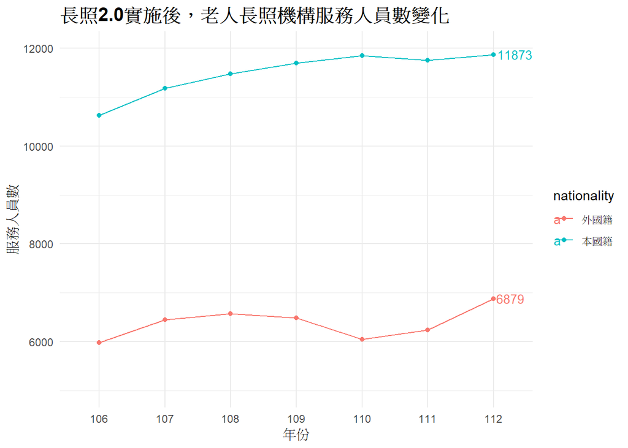

```r
trend_data %>%
    filter(year %in% c("106","107","108","109","110","111","112")) %>%
    ggplot() +
    aes(x = year, y = num, colour = nationality, group = nationality) +
    geom_line()+
    geom_point()+
    coord_cartesian(ylim = c(5000, 12000)) +
    labs(y = "服務人員數", x = "年份",
         title = "長照2.0實施後，老人長照機構服務人員數變化")+
    geom_text(data = subset(trend_data ,year == 112),
            aes(label = num), hjust = -0.1, size = 3.5, nudge_y = 0.01) +
    theme_minimal() +
    theme(plot.title = element_text(size = 15, face = "bold"))
```

## 結果詮釋

### 圖一：各縣市老人長照機構僱用外籍服務人員比例

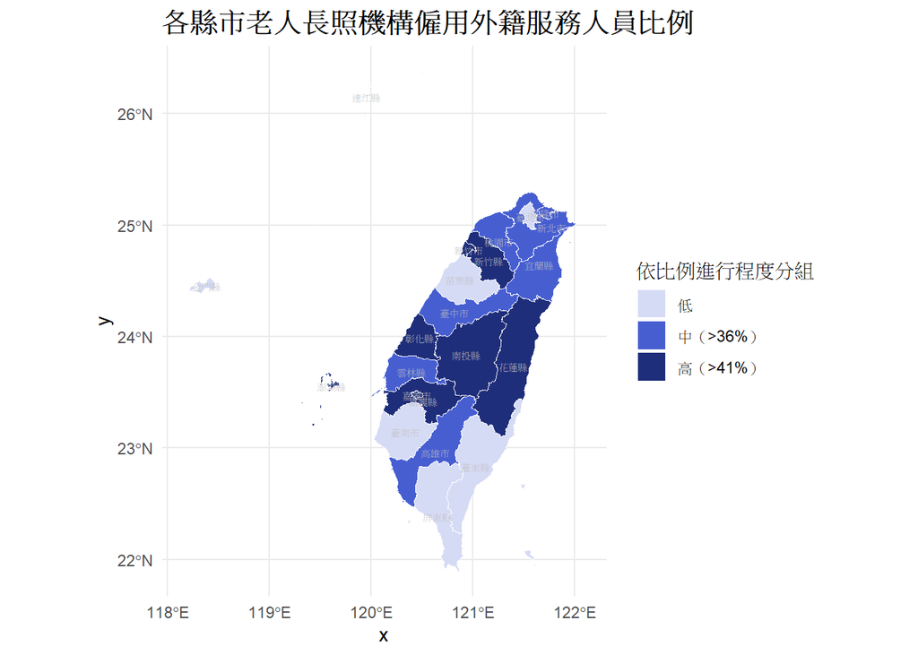

```r
map %>%
    ggplot(aes(fill = group)) +
    geom_sf(color="white", size=0.1) +
    scale_fill_manual(values = c(
    "低" = "#D6DBF5",
    "中（>36%）" = "#475ED1",
    "高（>41%）" = "#1F2E7A" )) +
    labs(fill = "依比例進行程度分組",
    title = "各縣市老人長照機構僱用外籍服務人員比例")+
    theme_minimal() +
    theme(plot.title = element_text(size = 15, face = "bold"))+
    geom_sf_text(aes(label = COUNTYNAME), size = 2, color = "gray")
```

### 圖二：長照2.0實施後，老人長照機構服務人員數變化

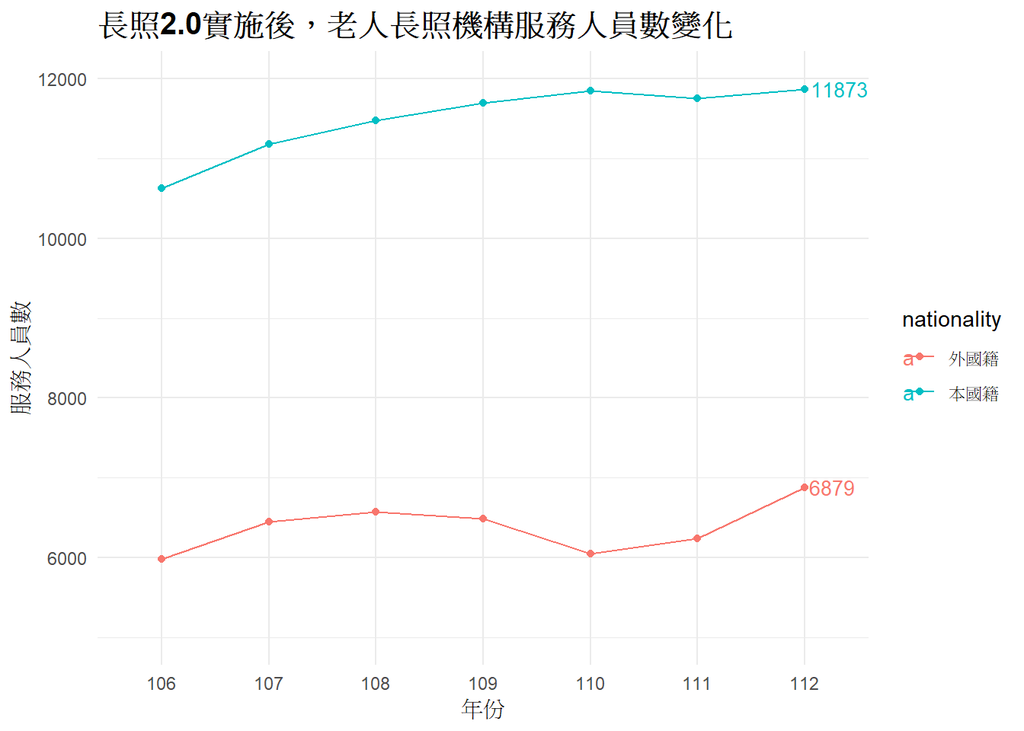

```r
trend_data %>%
    filter(year %in% c("106","107","108","109","110","111","112")) %>%
    ggplot() +
    aes(x = year, y = num, colour = nationality, group = nationality) +
    geom_line()+
    geom_point()+
    coord_cartesian(ylim = c(5000, 12000)) +
    labs(y = "服務人員數", x = "年份",
         title = "長照2.0實施後，老人長照機構服務人員數變化")+
    geom_text(data = subset(trend_data ,year == 112),
            aes(label = num), hjust = -0.1, size = 3.5, nudge_y = 0.01) +
    theme_minimal() +
    theme(plot.title = element_text(size = 15, face = "bold"))
```

說明：《長期照顧十年計劃2.0》自106年開始實施，政策包含持續擴大培訓及培育相關人力，以滿足人力需求，其中政府指出，當時最缺乏的是在第一線服務的照顧服務人員。圖一的地圖顯示，在112年時，大部分縣市外國籍服務人員的比例大於35%，其中新竹縣/市、花蓮縣、彰化縣、嘉義縣/市、南投縣等依賴外籍移工的情況更明顯。透過圖二，可發現自長照2.0實施以來，本國籍及外國籍的服務人員數量皆成長有限，但外國籍的增加率（15%）略高於本國籍（11.7%），顯示相關政策在增加本國服務人力上仍有不足之處。整體來看，除了疫情期間外籍人數有所下降外，外籍移工的服務在台灣的老人長照機構中仍相當重要。